# P2-analysis.Rmd

Aidan Burk

2024-05-06

## Introduction

The birthwt dataset has data collected by David W. Hosmer & Stanley Lemeshow at Baystate Medical Center, Springfield, Massachusetts during 1986, with 189 observations, and variables including infant birth weight in grams, mother’s weight in pounds at last menstrual period, and smoking status during pregnancy. This analysis is for studying how mother’s weight at last menstrual period and smoking status affect infant birth weight. (Source: Hosmer, D.W. and Lemeshow, S. (1989) Applied Logistic Regression. New York: Wiley)

## Data

Summary of numeric variables

| Variable | Min. | 1st Qu. | Median | Mean | 3rd Qu. | Max. |
| --- | --- | --- | --- | --- | --- | --- |
| Birth weight | 709 | 2414 | 2977 | 2944.5873 | 3487 | 4990 |
| Last menstrual period weight | 80 | 110 | 121 | 129.8148 | 140 | 250 |

Summary of birth weight for mothers who didn’t smoke during pregnancy & mothers who smoked during pregnancy

| Smoke | Obervations | Mean bwt | Sd bwt |
| --- | --- | --- | --- |
| No | 115 | 3055.696 | 752.6566 |
| Yes | 74 | 2771.919 | 659.6349 |

The figure below displays a scatterplot of mother’s weight at last menstrual period versus birth weight and smoking status. The plot suggests a slight increase in birth weight as last menstrual period weight increases. When comparing those who smoked during pregnancy to those who didn’t, this figure shows birth weight to generally be slightly lower for those who smoked, with a range of 709 to 4238, which is lower and less wide compared to the range of those who didn’t smoke (1021 to 4990).

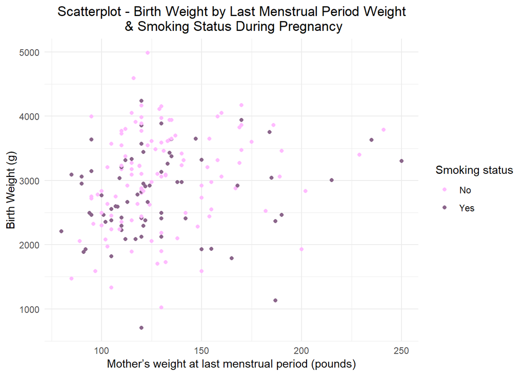

## Results

Because the response variable (Birth weight) is continuous and the explanatory variables include a continuous & categorical variable, we will fit a multiple linear regression model for birth weight on last menstrual period weight and smoking status. A scatterplot with regression lines indicates no significant interaction between the explanatory variables.

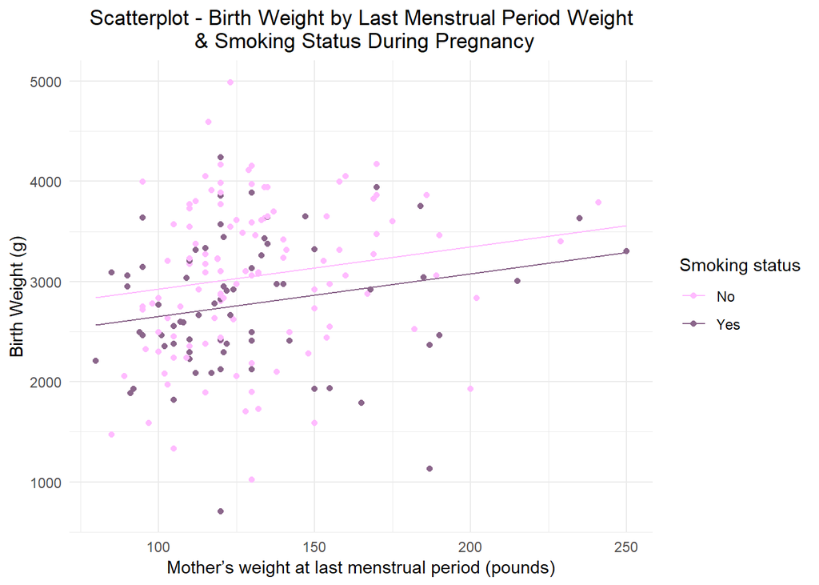

The structure of the multiple regression model is
$$Y_i=\beta_0+\beta_1X_{i,1}+\beta_2X_{i,2}+\epsilon_i$$
where $Y_i$ is birth weight, $X_{i,1}$ is the mother’s last menstrual period weight, $X_{i,2}$ is smoking status (No = 0, Yes = 1), & $\epsilon_i$ is the error.

The 95% confidence interval for the effect of mother’s last menstrual period weight on birth weight is 0.9, 7.57, which means that with 95% confidence, when last menstrual period weight increases by 1 pound, birth weight increases between 0.9 & 7.57 grams.

The 95% confidence interval for the effect of smoking status on birth weight is -480.39, -63.77, which means that with 95% confidence, the change in birth weight between not smoking during pregnancy & smoking during pregnancy is a decrease between 63.77 & 480.39 grams.

Diagnostic plots are included below to help evaluate model assumptions.

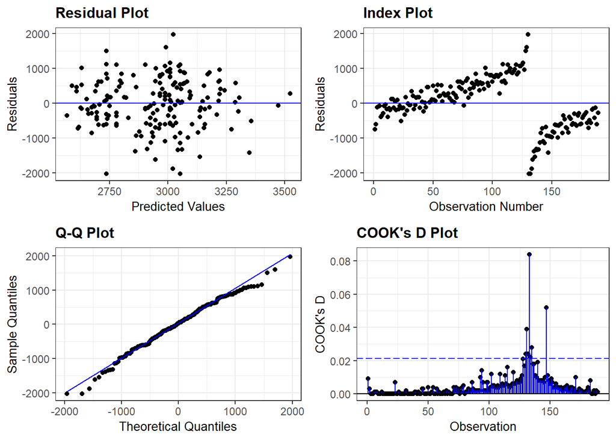

Below is a plot of the estimated birth weight with 95% confidence intervals. As seen with the original data, birth weight generally increases a slight amount when last menstrual period weight increases, and is slightly higher for those who didn’t smoke during pregnancy than for those who smoked.

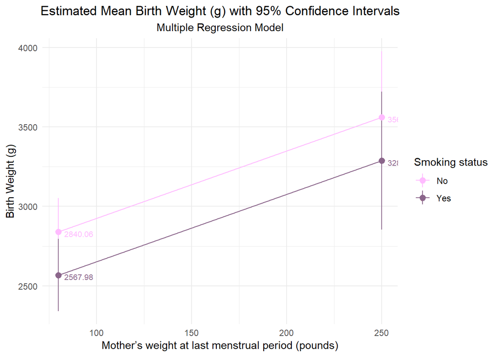

## Discussion

Using data collected from Baystate Medical Center, Springfield, Massachusetts by David W. Hosmer & Stanley Lemeshow in 1986, we performed multiple linear regression analysis, modelling infant birth weight on mother’s weight at last menstrual period and smoking status during pregnancy. We found that increasing weight at last menstrual period is associated with a slight increase in infant birth weight, and when comparing smoking status, smoking during pregnancy is associated with a generally lower birth weight than not smoking during pregnancy.

Because the data were not randomized as far as we know, our results on the effect of last menstrual period weight and smoking status on infant birth weight cannot be interpreted as causal, and since the data are not a random sample from any population, we cannot justifiably extend these results to a larger population.